# Treatment Effects in Staggered Adoption Designs with Non-Parallel Trends

Brantly Callaway

brantly.callaway@uga.edu

University of Georgia

Emmanuel Tsyawo

emmanuel.tsyawo@um6p.ma

FGSES, Universit'e Mohammed VI Polytechnique

November 19, 2023

## Introduction

$\newcommand{\E}{\mathbb{E}} \newcommand{\E}{\mathbb{E}} \newcommand{\var}{\mathrm{var}} \newcommand{\cov}{\mathrm{cov}} \newcommand{\Var}{\mathrm{var}} \newcommand{\Cov}{\mathrm{cov}} \newcommand{\Corr}{\mathrm{corr}} \newcommand{\corr}{\mathrm{corr}} \newcommand{\L}{\mathrm{L}} \renewcommand{\P}{\mathrm{P}} \newcommand{\independent}{{\perp\!\!\!\perp}} \newcommand{\indicator}[1]{ \mathbf{1}\{#1\} }$Setting of the paper: Researcher interested in learning about the causal effect of a binary treatment and has access to a few periods of panel data

- In economics, by far the most common approach in this setting is to use difference-in-differences (DID).

In the current paper, we will think about:

- Cases where the parallel trends assumption could be violated
- Applications where there is staggered treatment adoption
- How to exploit staggered treatment adoption to allow for violations of parallel trends while still recovering the same target causal effect parameters

## Introduction

- Parallel trends assumption: $\E[\Delta Y_t(0) | D=1] = \E[\Delta Y_t(0) | D=0]$
- DID is different from other quasi-experimental (e.g., random assignment, IV, RD) approaches to policy evaluation in that it inherently relies on functional form assumptions
  $$\begin{align*}
  Y_{it}(0) = \theta_t + \eta_i + e_{it}
  \end{align*}$$
  where the distribution of $\eta_i$ can differ arbitrarily across groups, but $\E[e_{it}|\eta_i, D] = \E[e_{it} | \eta_i] = 0$

## Introduction

- That the model for $Y_{it}(0)$ depends on time and unit-specific unobserved heterogneity is in-line with a long history of economic models, but the additive separability between time effects and unobserved heterogeneity is often harder to justify
  - And, in (probably most) applications, we simply do not know if it is reasonable or not
- Therefore, most DID applications in economics include an event study plot that checks parallel trends in pre-treatment periods. This is implicitly a test of the additive separability in the previous model for untreated potential outcomes.

## Deryugina (2017), Y: gov’t transfers, D: hurricane

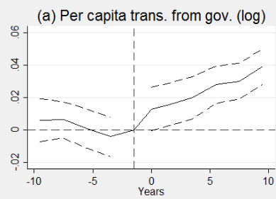

## Callaway and Sant’Anna (2021), Y: employment, D: min. wage

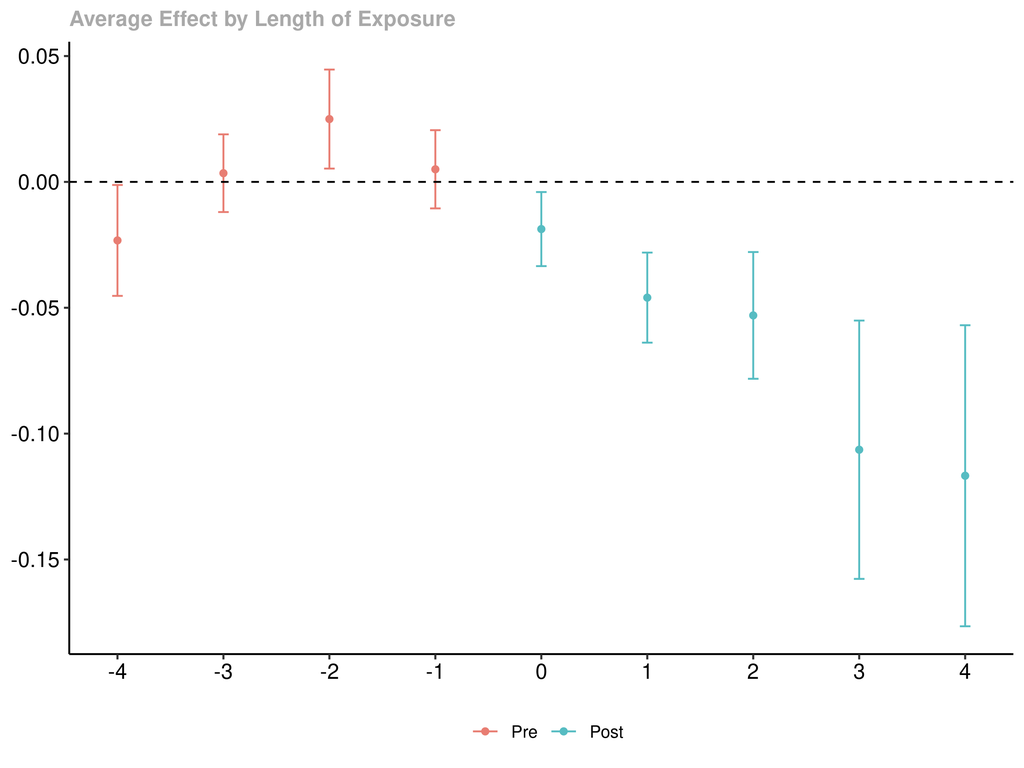

## Some ideas

- Allow for certain violations of parallel trends ($\implies$ bounds on causal effect parameters) often connected to the magnitude of the violations of parallel trends in pre-treatment periods (Manski and Pepper 2018; Rambachan and Roth 2023; Ban and Kedagni 2022)
- Consider alternative model for untreated potential outcomes
  - That’s what we will do in this paper!
  - Using (arguably) the most naturally connected approach to DID, interactive fixed effects (IFE)
  - (I think) IFE is closely connected to the ways that “bounding approaches” allow for violations of parallel trends…
- Running Example: Causal effect of $\underbrace{\textrm{job displacement}}_{\textrm{treatment}}$ on a $\underbrace{\textrm{person's earnings}}_{\textrm{outcome}}$

## IFE Model for Untreated Potential Outcomes

An intermediate case is an interactive fixed effects model for untreated potential outcomes:
$$\begin{align*}
Y_{it}(0) = \theta_t + \eta_i + \lambda_i F_t + e_{it}
\end{align*}$$

- $\lambda_i$ is often referred to as “factor loading” (notation above implies that this is a scalar, but you can allow for higher dimension)
- $F_t$ is often referred to as a “factor”
- $e_{it}$ is idioyncratic in the sense that $\E[e_{it} | \eta_i, \lambda_i, D_i] = 0$

In our context, though, it makes sense to interpret these as

- $\lambda_i$ unobserved heterogeneity (e.g., individual’s unobserved “ability”)
- $F_t$ the time-varying “return” unobserved heterogeneity (e.g., return to “ability”)

## Interactive Fixed Effects

Interactive fixed effects models allow for violations of parallel trends:

$$\begin{align*}
\E[\Delta Y_{it}(0) | D_i = d] = \Delta \theta_t + \E[\lambda_i|D_i=d]\Delta F_t
\end{align*}$$
which can vary across groups.

Example: If $\lambda_i$ is “ability” and $F_t$ is increasing over time, then (even in the absence of the treatment) groups with higher mean “ability” will tend to increase outcomes more over time than less skilled groups

Special Cases:

- Observed $\lambda_i \implies$ regression adjustment
- $F_t = t \implies$ unit-specific linear trend

But allowing $F_t$ to vary arbitrarily is harder…[[More details]]

## Staggered Treatment Adoption

Many of the insights of recent work no DID have been in the context of staggered treatment adoption

- $\implies$ there is variation in treatment timing across units
- de Chaisemartin and D’Haultfœuille (2020), Goodman-Bacon (2021), Callaway and Sant’Anna (2021), Sun and Abraham (2021), among others
- These papers all treat staggered treatment adoption as a nuisance, and
  - Show limitations of two-way fixed regressions for implementing DID identification strategies
  - Provide alternative estimation strategies
- In the current paper, we will exploit staggered treatment adoption in order to identify causal effect parameters

## Notation / Data / Setup

Observed data: $\{Y_{i1}, Y_{i2}, \ldots Y_{i\mathcal{T}}, D_{i1}, D_{i2}, \ldots, D_{i\mathcal{T}}\}_{i=1}^n$

- $\mathcal{T}$ time periods
- No one treated in the first time period (i.e., $D_{i1} = 0$)
- Staggered treatment adoption: for $t=2,\ldots,\mathcal{T}$, $D_{it-1} = 1 \implies D_{it}=1$.
- A unit’s group $G_i$ is the time period when it becomes treated. By convention, set $G_i = \infty$ for units that do not participate in the treatment in any period.
- Potential outcomes: $Y_{it}(g)$, $Y_{it}(\infty)$ is untreated potential outcome
- Observed outcomes: $Y_{it} = Y_{it}(G_i)$
- No anticipation: For $t < G_i$, $Y_{it} = Y_{it}(\infty)$

## Target Parameters

Following CS-2021, we target group-time average treatment effects:
$$\begin{align*}
ATT(g,t) = \E[Y_{it}(g) - Y_{it}(\infty) | G=g]
\end{align*}$$

- Group-time average treatment effects are the natural building block for other common target parameters in DID applications such as event studies or an overall $ATT$ (see Callaway and Sant’Anna (2021) for more details)
- Back to DID for a moment: Under parallel trends,
  $$\begin{align*}
  ATT(g,t) = \E[Y_{it} - Y_{ig-1} | G=g] - \E[Y_{it} - Y_{ig-1} | G=g']
  \end{align*}$$
  for any $g' > t$ (i.e., any group that is not-yet-treated by period $t$)
  - $\implies$ $ATT(g,t)$ is often over-identified (OI)
  - Marcus and Sant’Anna (2021) OI $\rightarrow$ more efficiently estimate $ATT(g,t)$
  - This paper: OI $\rightarrow$ relax parallel trends

## Recovering $ATT(g,t)$ with fixed-$\mathcal{T}$ approaches

Very Simple Case:

- $\mathcal{T}=4$
- 3 groups: 3, 4, $\infty$
- We will target $ATT(3,3) = \E[\Delta Y_{i3} | G_i=3] - \underbrace{\E[\Delta Y_{i3}(0) | G_i=3]}_{\textrm{have to figure out}}$ In this case, given the IFE model for untreated potential outcomes, we have:
  $$\begin{align*}
  \Delta Y_{i3}(0) &= \Delta \theta_3 + \lambda_i \Delta F_3 + \Delta e_{i3} \\
  \Delta Y_{i2}(0) &= \Delta \theta_2 + \lambda_i \Delta F_2 + \Delta e_{i2} \\
  \end{align*}$$
  The last equation implies that
  $$\begin{align*}
  \lambda_i = \Delta F_2^{-1}\Big( \Delta Y_{i2}(0) - \Delta \theta_2 - \Delta e_{i2} \Big)
  \end{align*}$$
  Plugging this back into the first equation (and combining terms), we have $\rightarrow$

## Fixed-$\mathcal{T}$ approaches

From last slide, combining terms we have that

$$\begin{align*}
\Delta Y_{i3}(0) = \underbrace{\Big(\Delta \theta_3 - \frac{\Delta F_3}{\Delta F_2} \Delta \theta_2 \Big)}_{=: \theta_3^*} + \underbrace{\frac{\Delta F_3}{\Delta F_2}}_{=: F_3^*} \Delta Y_{i2}(0) + \underbrace{\Delta e_{i3} - \frac{\Delta F_3}{\Delta F_2} \Delta e_{i2}}_{=: v_{i3}}
\end{align*}$$

Now (momentarily) suppose that we (somehow) know $\theta_3^*$ and $F_3^*$. Then,

$$\begin{align*}
\E[\Delta Y_{i3}(0) | G_i=3] = \theta_3^* + F_3^* \underbrace{\E[\Delta Y_{i2}(0) | G_i = 3]}_{\textrm{identified}} + \underbrace{\E[v_{i3}|G_i=3]}_{=0}
\end{align*}$$

$\implies$ this term is identified; hence, we can recover $ATT(3,3)$.

## Fixed-$\mathcal{T}$ approaches

From last slide, combining terms we have that

$$\begin{align*}
\Delta Y_{i3}(0) = \underbrace{\Big(\Delta \theta_3 - \frac{\Delta F_3}{\Delta F_2} \Delta \theta_2 \Big)}_{=: \theta_3^*} + \underbrace{\frac{\Delta F_3}{\Delta F_2}}_{=: F_3^*} \Delta Y_{i2}(0) + \underbrace{\Delta e_{i3} - \frac{\Delta F_3}{\Delta F_2} \Delta e_{i2}}_{=: v_{i3}}
\end{align*}$$

How can we recover $\theta_3^*$ and $F_3^*$?

Notice: this involves untreated potential outcomes through period 3, and we have groups 4 and $\infty$ for which we observe these untreated potential outcomes. This suggests using those groups.

- However, this is not so simple because, by construction, $\Delta Y_{i2}(0)$ is correlated with $v_{i3}$ (note: $v_{i3}$ contains $\Delta e_{i2} \implies$ they will be correlated by construction)
- We need some exogenous variation (IV) to recover the parameters $\rightarrow$

## Fixed-$\mathcal{T}$ approaches

There are a number of different ideas here:

- Make additional assumptions ruling out serial correlation in $e_{it}$ $\implies$ can use lags of outcomes as instruments (Imbens, Kallus, and Mao 2021):
  - But this is seen as a strong assumption in many applications (Bertrand, Duflo, and Mullainathan 2004)
- Alternatively can introduce covariates and make auxiliary assumptions about them (Callaway and Karami 2023; Brown and Butts 2023; Brown, Butts, and Westerlund 2023)
- However, it turns out that, with staggered treatment adoption, you can recover $ATT(3,3)$ essentially for free

## Our Approach

In particular, notice that, given that we have two distinct untreated groups in period 3: group 4 and group $\infty$, then we have two moment conditions:

$$\begin{align*}
\E[\Delta Y_{i3}(0) | G=4] &= \theta_3^* + F_3^* \E[\Delta Y_{i2}(0) | G=4] \\
\E[\Delta Y_{i3}(0) | G=\infty] &= \theta_3^* + F_3^* \E[\Delta Y_{i2}(0) | G=\infty] \\
\end{align*}$$
We can solve these for $\theta_3^*$ and $F_3^*$:
$$\begin{align*}
F_3^* = \frac{\E[\Delta Y_{i3}|G_i=\infty] - \E[\Delta Y_{i3}|G_i=4]}{\E[\Delta Y_{i2}|G_i=\infty] - \E[\Delta Y_{i2}|G_i=4]}
\end{align*}$$

$\implies$ we can recover $ATT(3,3)$.

## Additional Details about Identification

An important issue for IFE approaches is determining how many IFEs terms there are (e.g., 0, 1, 2, …)

- Interestingly, there is a tight link in our approach between this “model selection” and identification
  - In cases where parallel trends holds in pre-treatment periods $\implies$ 0 IFEs, failure of relevance condition if we try to include 1 IFE
  - In cases where parallel trends is violated in pre-treatment periods (essentially) $\implies$ (at least) 1 IFE, relevance condition holds for recovering $ATT(g,t)$.

DID infrastructure related to pre-testing also carries over to our approach

[[Detailed Version]]

## Discussion

- Can scale this argument up for more periods, groups, and IFEs (see paper)
- Relative to other approaches to dealing with IFEs:
  - We do not need a large number of periods or extra auxiliary assumptions
  - Only need there to be staggered treatment adoption
  - The main drawback is that can’t recover as many $ATT(g,t)$’s; e.g., in this example, we can’t recover $ATT(3,4)$ or $ATT(4,4)$ which might be recoverable in other settings
- Generality: we have talked about IFE models, but
  - There are other types of models that need extra moment conditions (e.g., dynamic panel data model for $Y_{it}(0)$), could use the same sort of idea there

## Conclusion

Comments very welcome: `brantly.callaway@uga.edu`

Code: `staggered_ife2` function in `ife` package in R, available at github.com/bcallaway11/ife

# Appendix

## References

Abadie, Alberto, Alexis Diamond, and Jens Hainmueller. 2010. “Synthetic Control Methods for Comparative Case Studies: Estimating the Effect of California’s Tobacco Control Program.” *Journal of the American Statistical Association* 105 (490): 493–505.

Arkhangelsky, Dmitry, Susan Athey, David A Hirshberg, Guido W Imbens, and Stefan Wager. 2021. “Synthetic Difference-in-Differences.” *American Economic Review* 111 (12): 4088–118.

Bai, Jushan. 2009. “Panel Data Models with Interactive Fixed Effects.” *Econometrica* 77 (4): 1229–79.

Ban, Kyunghoon, and Desire Kedagni. 2022. “Generalized Difference-in-Differences Models: Robust Bounds.”

Bertrand, Marianne, Esther Duflo, and Sendhil Mullainathan. 2004. “How Much Should We Trust Differences-in-Differences Estimates?” *The Quarterly Journal of Economics* 119 (1): 249–75.

Brown, Nicholas, and Kyle Butts. 2023. “Dynamic Treatment Effect Estimation with Interactive Fixed Effects and Short Panels.”

Brown, Nicholas, Kyle Butts, and Joakim Westerlund. 2023. “Simple Difference-in-Differences Estimation in Fixed-t Panels.”

Callaway, Brantly, and Sonia Karami. 2023. “Treatment Effects in Interactive Fixed Effects Models with a Small Number of Time Periods.” *Journal of Econometrics* 233 (1): 184–208.

Callaway, Brantly, and Pedro HC Sant’Anna. 2021. “Difference-in-Differences with Multiple Time Periods.” *Journal of Econometrics* 225 (2): 200–230.

de Chaisemartin, Clement, and Xavier D’Haultfœuille. 2020. “Two-Way Fixed Effects Estimators with Heterogeneous Treatment Effects.” *American Economic Review* 110 (9): 2964–96.

Deryugina, Tatyana. 2017. “The Fiscal Cost of Hurricanes: Disaster Aid Versus Social Insurance.” *American Economic Journal: Economic Policy* 9 (3): 168–98.

Gobillon, Laurent, and Thierry Magnac. 2016. “Regional Policy Evaluation: Interactive Fixed Effects and Synthetic Controls.” *Review of Economics and Statistics* 98 (3): 535–51.

Goodman-Bacon, Andrew. 2021. “Difference-in-Differences with Variation in Treatment Timing.” *Journal of Econometrics* 225 (2): 254–77.

Imbens, Guido, Nathan Kallus, and Xiaojie Mao. 2021. “Controlling for Unmeasured Confounding in Panel Data Using Minimal Bridge Functions: From Two-Way Fixed Effects to Factor Models.”

Manski, Charles F, and John V Pepper. 2018. “How Do Right-to-Carry Laws Affect Crime Rates? Coping with Ambiguity Using Bounded-Variation Assumptions.” *Review of Economics and Statistics* 100 (2): 232–44.

Marcus, Michelle, and Pedro HC Sant’Anna. 2021. “The Role of Parallel Trends in Event Study Settings: An Application to Environmental Economics.” *Journal of the Association of Environmental and Resource Economists* 8 (2): 235–75.

Rambachan, Ashesh, and Jonathan Roth. 2023. “A More Credible Approach to Parallel Trends.” *Review of Economic Studies*, rdad018.

Sun, Liyang, and Sarah Abraham. 2021. “Estimating Dynamic Treatment Effects in Event Studies with Heterogeneous Treatment Effects.” *Journal of Econometrics* 225 (2): 175–99.

Xu, Yiqing. 2017. “Generalized Synthetic Control Method: Causal Inference with Interactive Fixed Effects Models.” *Political Analysis* 25 (1): 57–76.

## Interactive Fixed Effects Examples

Interactive fixed effects models for untreated potential outcomes generalize some other important cases:

Example 1: Suppose we observe $\lambda_i$, then this amounts to the regression adjustment version of DID with a time-invariant covariate

Example 2: Suppose you know that $F_t = t$, then this leads to a *unit-specific linear trend model*:
$$\begin{align*}
Y_{it}(0) = \theta_t + \eta_i + \lambda_i t + e_{it}
\end{align*}$$

## Interactive Fixed Effects Examples (cont’d)

To allow for $F_t$ to change arbitrarily over time is harder…

Example 3: Interactive fixed effects models also provide a connection to “large-T” approaches such as synthetic control and synthetic DID (Abadie, Diamond, and Hainmueller 2010; Arkhangelsky et al. 2021)

- e.g., one of the motivations of the SCM in ADH-2010 is that (given large-T) constructing a synthetic control can balance the factor loadings in an interactive fixed effects model for untreated potential outcomes

[[Back]]

## How can you recover $ATT(g,t)$ in an IFE setting?

There are a lot of ideas. Probably the most prominent idea is to directly estimate the model for untreated potential outcomes and impute untreated potential outcomes

- See (Xu 2017; Gobillon and Magnac 2016) for substantial detail on this front
- For example, Xu (2017) uses Bai (2009) principal components approach to estimate the model.
  - This is a bit different in spirit from what we have been doing before as this argument requires the number of time periods to be “large”

## Additional Details about Identification

For the IFE model not to “reduce” to two-way fixed effects, we need to rule out both:

- $\E[\lambda_i | G_i=3] = \E[\lambda_i | G_i=4] = \E[\lambda_i | G_i = \infty]$
- $F_1 = F_2 = F_3 = F_4$

But we need to strengthen these for our approach to work

## What could go right/wrong?

Relevance: We additionally need that both

- $\E[\lambda_i | G_i=4] \neq \E[\lambda_i | G_i = \infty]$
- $F_2 \neq F_1$

Otherwise, $G_i = 4$ and $G_i = \infty$ have the same trend between the first two periods.

Case 1: $F_2 \neq F_1$ but $\E[\lambda_i | G_i=3] \neq \E[\lambda_i | G_i=4] = \E[\lambda_i | G_i = \infty]$

- $\implies$ our approach won’t work, but you would be able to see that $G_i=3$ is trending differently from $G_i=4$ and $G_i=\infty$
- Effectively, $G_i=4$ and $G_i=\infty$ are the “same” comparison group, so we cannot deal with the IFE, but we can reject parallel trends in the same way as typical DID approaches

## What could go right/wrong?

Relevance: We additionally need that both

- $\E[\lambda_i | G_i=4] \neq \E[\lambda_i | G_i = \infty]$
- $F_2 \neq F_1$

Otherwise, $G_i = 4$ and $G_i = \infty$ have the same trend between the first two periods.

Case 2: $\E[\lambda_i | G_i=4] \neq \E[\lambda_i | G_i = \infty]$ but $F_3 \neq F_2 = F_1$

- $\implies$ our approach won’t work, but (I think) no approach would work here
- In this case, all groups trend the same between periods 1 and 2, so it looks like parallel trends holds. Here it does hold in pre-treatment periods, but it is violated in post-treatment periods
- This is closely related to the saying: “parallel trends is fundamentally untestable”

## What could go right/wrong?

Exogeneity:

- Can’t directly test, but a lot of the DID infrastructure carries over here.
- For DID, can “pre-test” parallel trends if there is more than 1 pre-treatment period
- For our approach, we need 2 pre-treatment periods to identify $ATT(g,t)$, but if there are more pre-treatment periods then we can pre-test
- If there are more factors (say $R$), we need $R+1$ pre-treatment periods to recover $ATT(g,t)$, but if there are more pre-treatment periods then we can pre-test.

[[Back]]